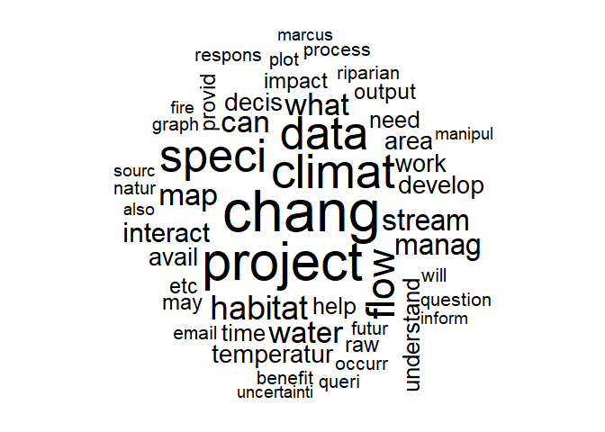

## Initial emails

Email sent to the following:

Celine Gallon Celine.Gallon@waterboards.ca.gov; Renee Purdy Renee.Purdy@waterboards.ca.gov; Mary Larson Mary.Larson@wildlife.ca.gov; Jennifer.Pareti Jennifer.Pareti@wildlife.ca.gov; Rosi Dagit rosidagit@gmail.com; Sabrina Drill sldrill@ucdavis.edu; Chris Medak christine_medak@fws.gov; Jennifer Mongolo jmongolo@planning.lacounty.gov

I just wanted to formally introduce myself and follow up with some specifics from Jenny’s email. Feel free to give me a ring if any of this needs clarification: 7147553217

Our plan is to create an interactive data visualization tool that will enhance our understanding of climate change effects on riparian dependent species in the LA/Ventura region (examples here and here). An objective of this deliverable is to present the information in a way that is meaningful to the interests of the advisory committee and others that can benefit from this project. To develop our vision, we are asking for feedback that will help us understand the needs of our group and how this app can inform their interests.

• What regulatory or management decisions do you anticipate would benefit from the results of this project on climate induced changes in flow and temperature on stream/riparian species? • What sources of uncertainty are of most concern to your decision making process (e.g. climate projections, water management, species occurrence, future invasions, etc.)? • What types of data/information output would be most beneficial to your work (e.g. raw data queries, graphs and plots that can be manipulated, interactive maps)? – please provide your top TWO choices.

These questions are purposefully general to help us develop a broad objective for the application. We’ll use your feedback to develop a prototype that will be refined with help from the group as we move forward.

I really appreciate your time in answering these questions and am looking forward to working on this interesting project.

Best,

Marcus

## Response

### Sabrina Drill phone call 6/22

Biologist with UC coop extension, ag and natural resources covering LA and Ventura county, fish biologist by training, natural resources advisory by career

Needs:

- Focus on how changes in flow/precip by location affect **stream habitat**, hydrogeomorphological changes, particularly sedimentation and substrate changes as related to salmonid habitat
- Impacts of fire and relation to climate, how will climate change increase severity/occurrence of fires and what does that mean for streams
- Approach to prioritize barrier removal projects - can we develop an app that lets of evaluate connectivity of stream networks and how doe sthat relate to climate change

Earlier email 4/19

Hi Marcus,

I just wanted to let you know I have this and am giving it some thought. I’m actually attending a meeting tomorrow to develop a collaborative approach to measuring and mitigating for Thomas Fire impacts to local streams. I also just read a really interesting report on extended impacts of invasive pests on willow forests in the Tijuana River Valley. I guess this is to say that I’m thinking about streamflow, sure, but also the more cumulative impacts of climate change on streams – I guess that might address your 2nd question.

I intend to keep mulling this over and will try to formulate a response for you next week, but I am really slammed, so you have my full permission to bug me if you don’t hear back.

### Rosi Dagit 4/18 (phone call)

Some key points from a phone call:

- Resource conservation district of Santa Monica Mountains
- desire for retrieving info from app - maps, data, summary plots, etc. to support project initiatives
- ability to extract raw data
- links between surface flow, connectivity and effects on bio, e.g. change in upstream flow propagates to upstream incursions of salinity, what does this do to habitat, species suitability ranges, etc., effects of fragmentation
- fright maps - best/worst case modelling scenarios and changes in species dists
- USGS Nathan Holste conducting similar modeling in LA river
- Wetlands Recovery Project - Shawn Kelly working with others to build similar apps

### Christine Medak, 4/20

Here is a response to your questions:

• What regulatory or management decisions do you anticipate would benefit from the results of this project on climate induced changes in flow and temperature on stream/riparian species?

The effects of climate change-related changes on water flow and temperature can be used as a surrogate for evaluating effects of human induced changes to water flow and temperature (e.g., reductions in wastewater discharges, increases in natural flow diversions…). Some questions we might ask: Will proposed changes in the magnitude, timing, and/or distribution of flows impact the productivity of the vireo or Santa Ana sucker in the project area? Are there management options available to emulate natural processes in the absence of sufficient environmental flows (i.e., thinning out canopy trees, importing spawning gravel)?

• What sources of uncertainty are of most concern to your decision making process (e.g. climate projections, water management, species occurrence, future invasions, etc.)?

We understand, generally, that natural stream processes (e.g., sediment transport, scour, deposition…) are important for maintaining suitable aquatic and riparian habitat conditions for native species and we have a good understanding of species habitat needs but we don’t have a good understanding of minimum base flows/subsurface flows and the frequency and magnitude of storm flows that are necessary to maintain suitable habitat. For example, the timing and magnitude of surface flows and/or groundwater necessary to maintain a structurally diverse riparian woodland (including understory, shrub and canopy layers) for the vireo are not well understood. Consultants often project only a fraction of the available water is necessary to support the habitat but there is little data available to support their projections. We would be interested in the development of monitoring programs for evaluating habitat response to changes in the hydrograph.

• What types of data/information output would be most beneficial to your work (e.g. raw data queries, graphs and plots that can be manipulated, interactive maps)? – please provide your top TWO choices.

Graphs (e.g., daily cfs, daily temperature) that are representative of the natural hydrograph in the LA Basin area and within different stream orders would be very helpful for comparison with anticipated changes to the hydrograph. It would also be helpful to understand the origin of data used to generate specific model outputs (maybe have a clickable link to source information). Often I have seen data presented as monthly or annual water available (in AF). This is not helpful for understanding the magnitude and frequency of flows necessary to maintain habitat.

Let me know if you are looking for more specific examples of projects or information needs that we have.

### Jennifer Mongolo 4/24

Hi Marcus, Here are my responses to your questions.

What regulatory or management decisions do you anticipate would benefit from the results of this project on climate induced changes in flow and temperature on stream/riparian species?

- Biological review of proposed development (e.g. CEQA review)
  - determining appropriate mitigation sites
  - determining appropriate buffer distances for proposed development
  - establishing mitigation ratios and findings of significance
- drafting/updating policies and regulations
- informing area plans, community standards districts, and general plan updates
- identifying areas both vulnerable and resilient to future sea-level rise

What sources of uncertainty are of most concern to your decision making process (e.g. climate projections, water management, species occurrence, future invasions, etc.)?

- climate projections, for example timing of raining season or shifts species response to seasons (or lack thereof). For instance, we apply special conditions to projects to restrict certain activities to specific times of year (i.e. no grading during rainy season, conduct breeding bird surveys during nesting bird season, rare plant surveys in the spring, etc.) We put calendar year time frames on these activities based on historic climate data, but it is starting to become clear that the current time frames may need to be adjusted. It’s just not clear what the new time frames should be.
- influence of climate change on species range and distribution – for example, do we need to start looking for species in different places? Do we need better protections for certain habitats because the range is expected to become more restricted?
- impacts of frequent fires and ability of species to recover from fire events

What types of data/information output would be most beneficial to your work (e.g. raw data queries, graphs and plots that can be manipulated, interactive maps)? – please provide your top TWO choices.

- interactive maps showing a range of projections/scenarios
- geographic data that we can add to our own map applications.

Let me know if I can be of further assistance. Really excited to see what you come up with!

Thanks, Jen

### Jennifer Pareti 5/8

Hi Marcus, I apologize for the delay in getting back to you. Here is my feedback on the points that you listed:

• What regulatory or management decisions do you anticipate would benefit from the results of this project on climate induced changes in flow and temperature on stream/riparian species? Understanding habitat changes as it relates to quantity of available habitat for fish – identifying areas within streams likely to go dry/locations of persistent water. • What sources of uncertainty are of most concern to your decision making process (e.g. climate projections, water management, species occurrence, future invasions, etc.)? Water availability in persistent drought. Lack of scour in streams from fewer/weaker storm events. • What types of data/information output would be most beneficial to your work (e.g. raw data queries, graphs and plots that can be manipulated, interactive maps)? – please provide your top TWO choices. Interactive maps, graphs and plots that can be manipulated.

Thank you, Jennifer

### Kyle Evans (via Mary Larson) 5/9

Good morning Marcus,

I was asked by my supervisor Mary Larson to provide a bit of feedback for this project. I have ccd another CDFW biologist, Dana McCanne, on this email so he may provide any additional comments as he sees fit. I am a big fan of interactive maps for data visualization like the ones linked in your previous email. When it comes to riparian species (partially occurrence) there exists a large amount of spatially available data through CDFW BIOS and CalFlora. This is also the case with predictions in sea level rise (Ventura County is working on a large sea level rise project at the moment) and general trends in temperature and rainfall for southern California in the face of climate change.

I see the largest benefit of a project like this for my work would be highlighting potential areas of refugia or high quality habitat. By that I mean areas that may maintain cooler stream temperatures, summer base flows, and riparian cover in the face of predicted climate change models. These areas can then be overlaid with species occurrence available in BIOS or Calflora. I agree with you though that the greatest level of uncertainty at this point for riparian streams may be changes in water management and water policy.

For the data/information output I would prefer interactive maps in addition to raw data queries. Interactive maps provides that large scale spatial view of what data is available (or unavailable in many cases) and may help direct management decisions as it may highlight areas with a high risk of significant change due to climate change impacts. Moving away from the large scale spatial side I would also like the raw data queries. I think it’s important that we are able to run our own analysis and be able to see what data is being used in the model. I’m excited to see this project develop as this may help guide our future data collection and monitoring work to fill knowledge gaps highlighted here.

Kyle